# Code Through - Esquisse

Victor Vega

24 February 2021

# Introduction

This code through demonstrates how to create ‘ggplot2’ charts without having to produce the code from scratch using Esquisse. Esquisse has a user interface that allows you to drag and drop your data variables to create a visual. It allows you to create a variety of charts such as line graphs, bar charts, histograms, and more. I found this very Tableau-esque where you can easily place variables in the view and create various different visualizations. Being relatively new to R I found this tool extremely useful because it gives you a starting point that then allows you to further modify your code to get your desired visual.

## Content Overview

I will be using the ‘mtcars’ dataset in R to demonstrate how to create charts using Esquisse.

# Steps

## Packages Needed

In order to be able to complete this code through the following packages will be needed.

```r
#Load the packages in R
library(ggplot2)
library(esquisse)
library(shiny)
```

## mtcars Dataset

A look at the first few rows of the `mtcars` dataset.

```r
#Look at the mtcars dataset
head(mtcars)
```

|  | mpg | cyl | disp | hp | drat | wt | qsec | vs | am | gear | carb |
| --- | --- | --- | --- | --- | --- | --- | --- | --- | --- | --- | --- |
| Mazda RX4 | 21.0 | 6 | 160 | 110 | 3.90 | 2.620 | 16.46 | 0 | 1 | 4 | 4 |
| Mazda RX4 Wag | 21.0 | 6 | 160 | 110 | 3.90 | 2.875 | 17.02 | 0 | 1 | 4 | 4 |
| Datsun 710 | 22.8 | 4 | 108 | 93 | 3.85 | 2.320 | 18.61 | 1 | 1 | 4 | 1 |
| Hornet 4 Drive | 21.4 | 6 | 258 | 110 | 3.08 | 3.215 | 19.44 | 1 | 0 | 3 | 1 |
| Hornet Sportabout | 18.7 | 8 | 360 | 175 | 3.15 | 3.440 | 17.02 | 0 | 0 | 3 | 2 |
| Valiant | 18.1 | 6 | 225 | 105 | 2.76 | 3.460 | 20.22 | 1 | 0 | 3 | 1 |

## Opening Esquisse

The Esquisse user interface can be opened onto a dialog window, browser page, or R pane.

```r
#Load Esquisse onto dialog window
#esquisser(mtcars, viewer = "dialog")

#Load Esquisse onto browser
#esquisser(mtcars, viewer = "browser")

#Load Esquisse onto R pane
#esquisser(mtcars, viewer = "pane")
```

## Esquisse on a new dialog window

I chose to open Esquisse onto a new dialog window and this is the window lets you select your data and allows to change the data types on your variables if needed.

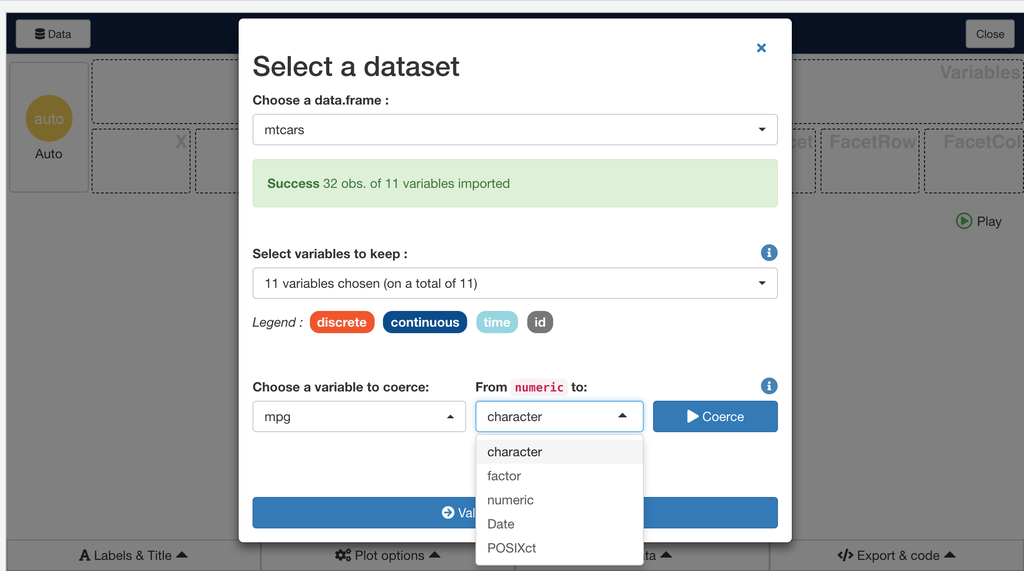

## Esquisse ggplot2 Builder

After clicking the *‘Validate imported data’* button it will take you to the chart builder (shown below). It displays your variables on the top and we can drag and drop the variables to the x-axis and y-axis. At the bottom of the window we can edit our title and labels, as well as change the color and theme of our visual.

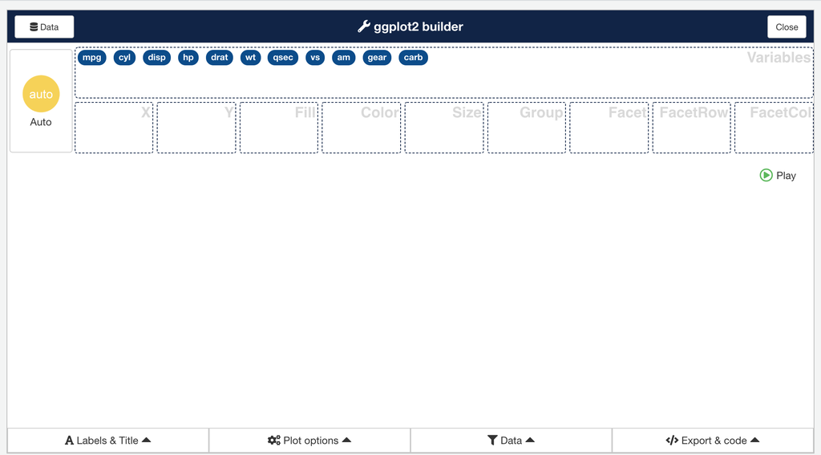

## Chart Example

I dragged `mpg` and `hp` to the view and made a chart to show the relationship between miles per gallon and horsepower. Clicking the *‘Labels & Title’* button it lets you edit the title and data labels on the visual. *‘Plot options’* lets you change the theme of the graph and size of the points. *‘Data’* allows you to filter your data. For example, I could have just looked at the relationship between miles per gallon and horsepower for 4 cylinder vehicles instead of all cylinders vehicles.

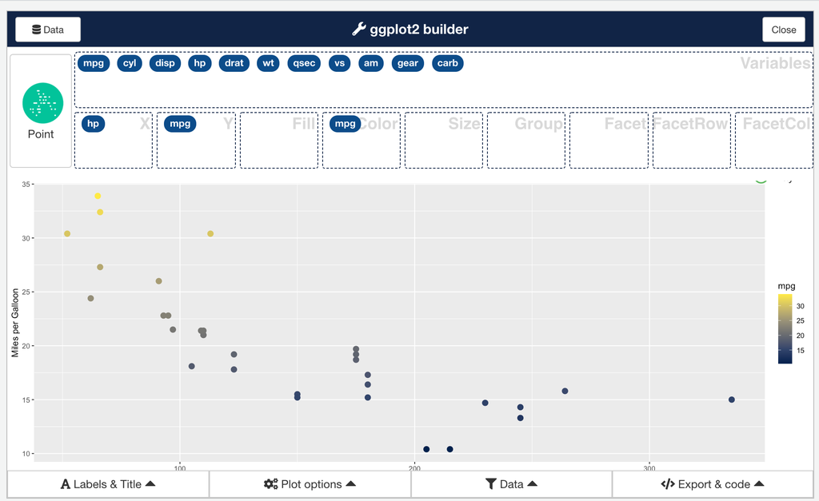

## Export your Code

Now that the chart is ready click *‘Export & code’* and select *‘Insert code in script’*. The chart’s code with be inserted to your file.

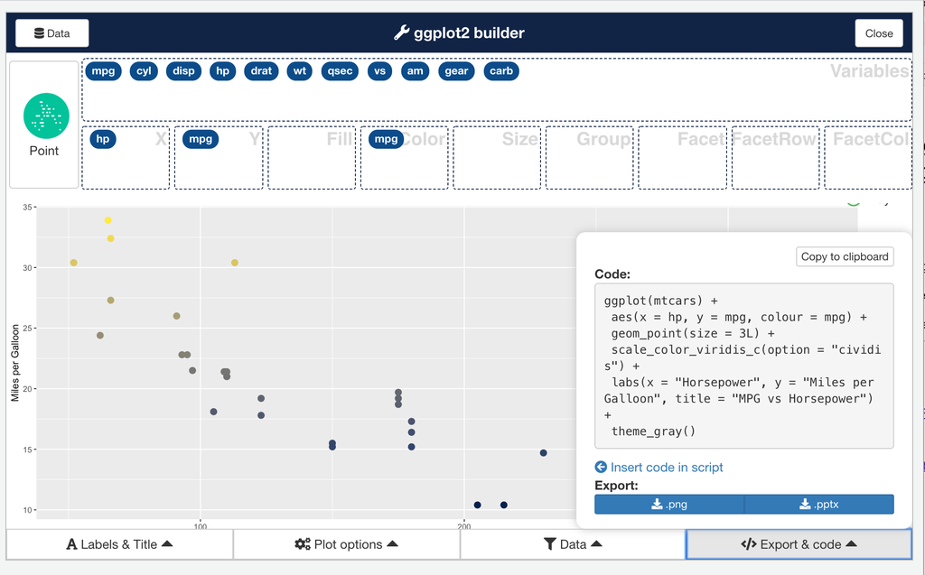

## Chart Created Using Esquisse

The following code is generated from Esquisse. Esquisse is powerful tool that helps in the process of developing your desired visual. Overall, it provides the code framework of how the graph and you can always build upon that code.

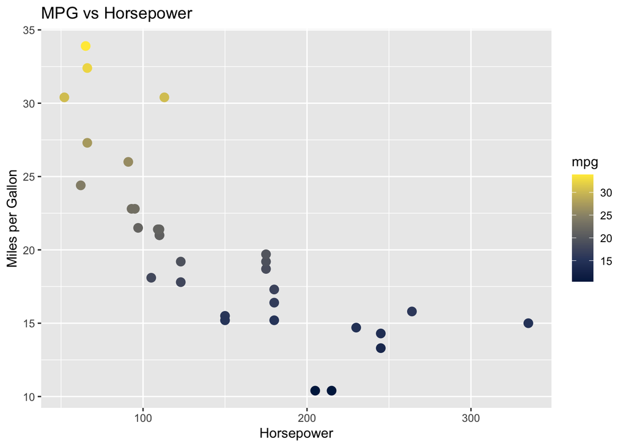

```r
library(ggplot2)

ggplot(mtcars) +
 aes(x = hp, y = mpg, colour = mpg) +
 geom_point(size = 3L) +
 scale_color_viridis_c(option = "cividis") +
 labs(x = "Horsepower", y = "Miles per Gallon", title = "MPG vs Horsepower") +
 theme_gray()
```

# Further Resources

Learn more about Esquisse and ggplot2 with the following:

- [Esquisse CRAN Documentation](https://cran.r-project.org/web/packages/esquisse/esquisse.pdf)
- [ggplot2 CRAN Documentation](https://cran.r-project.org/web/packages/ggplot2/ggplot2.pdf)

## Works Cited

This code through references the following sources:

- 8 Useful R Packages for Data Science You Aren’t Using (But Should!). Analytics Vidhya, https://www.analyticsvidhya.com/blog/2019/04/8-useful-r-packages-data-science/
- Getting Started with Esquisse. CRAN, https://cran.r-project.org/web/packages/esquisse/vignettes/get-started.html